# Loan Eligibility Predictor

#### Nobody98

#### Loan Eligibility Predictor

#### Python Pandas, Sklearn, yellowbrick

#### sklearn.datasets loan data

#### August '22

## Project Brief:

Dream Housing Finance company deals in all home loans. They have presence across all urban, semi urban and rural areas. Customer first apply for home loan after that company validates the customer eligibility for loan. Company wants to automate the loan eligibility process (real time) based on customer detail provided while filling online application form. These details are Gender, Marital Status, Education, Number of Dependents, Income, Loan Amount, Credit History and others. To automate this process, they have given a problem to identify the customers segments, those are eligible for loan amount so that they can specifically target these customers.

# Import All Packages

```python
from sklearn.linear_model import LogisticRegression
from sklearn.ensemble import RandomForestClassifier
from sklearn.tree import DecisionTreeClassifier
from xgboost import XGBClassifier

import numbers, random, warnings, time, pickle

from ast import Try, Break
from logging import exception
import warnings

from slowprint.slowprint import *
from multipledispatch import dispatch

from pandas_profiling import ProfileReport

import pandas as pd
import numpy as np
import seaborn as sb
import matplotlib.pyplot as plt

from sklearn.preprocessing import LabelEncoder

from sklearn.model_selection import train_test_split

from sklearn.metrics import accuracy_score, confusion_matrix, classification_report, precision_score
from yellowbrick.classifier.classification_report import classification_report as ClassificationReport
from yellowbrick.classifier import class_prediction_error

# For future reference, I found quicker versions of the two functions below; I blank out the old versions, the new
# versions are the ones I am using above.
# from yellowbrick.classifier import ClassificationReport # to visualise the classification report
#from yellowbrick.classifier import ClassPredictionError
```

```python
# sklearn keeps throwing error at the single observation prediction
warnings.filterwarnings("ignore")
```

# Pre-Processessing

```python
train = pd.read_csv("loan-train.csv")
test = pd.read_csv("loan-test.csv")


ProfileReport(train);
```

```python
print(f"Training data shape: {train.shape}\nTesting data shape: {test.shape}")
```

```
Training data shape: (614, 13)
Testing data shape: (367, 12)
```

```python
train.drop("Loan_ID", axis=1, inplace=True)
test.drop("Loan_ID", axis=1, inplace=True)
```

```python
# searches for the numeric data/columns with NANs and fills the hole with their modes.

num_cols = train.select_dtypes(include="number").columns

for col in num_cols:
    mode = train[col].dropna().mode()
    if col in test.columns:
        test[col].fillna(mode,axis=0, limit=None,inplace=True)
    elif col in train.columns:
        train[col].fillna(mode,axis=0, limit=None ,inplace=True)
```

```python
# checks if there are any remaining columns with null values
# fills the remaining NaS using padding

null_cols = []
for cols in train.columns:
    if train[cols].isna().sum()>0:
        null_cols.append(cols)

for col in null_cols:
    train[col].fillna(method="pad",axis=0, inplace=True)
    if col in test.columns:
        test[col].fillna(method="pad",axis=0, inplace=True)
```

```python
# Change categorical data to numerical data

encoder = LabelEncoder()

the_encoded = ["Property_Area", "Dependents"]

for col in the_encoded:
    train[col] = encoder.fit_transform(train[col])
    if col in test.columns:
        test[col] = encoder.fit_transform(test[col])
```

```python
# Manually changes the labels for all the text binary (e.g True and False) to numeric binary
# yes I could have use an encoder but I won't :-)

binaryDic = {"Male": int(1), "Female": int(0), "True": int(1), "False": int(0), True: int(1), False: int(0), "Yes": int(1), "No": int(0), "Graduate":int(1), "Not Graduate": int(0), "Y": int(1), "N":int(0), "1": int(1), "0":int(0)}

binary_cols = ["Married", "Gender", "Education","Loan_Status", "Self_Employed"]

for col in binary_cols:
    train[col].replace(binaryDic,inplace=True)
    if col in test.columns:
        test[col].replace(binaryDic, inplace=True)
```

```python
train['LoanAmount'].fillna(train['LoanAmount'].dropna().mean(), inplace=True)
```

```python
ProfileReport(train);
```

```python
ProfileReport(test);
```

```python
train.to_excel("loan-train-clean.xlsx")
test.to_excel('loan-test-clean.xlsx')
```

# Data Visualisation

Settings and options

```python
sb.set(context="paper")
```

### Correlation Matrix

```python
correlation = train.corr()
correlation.style.background_gradient(cmap='coolwarm').set_precision(4)
```

|  | Gender | Married | Dependents | Education | Self_Employed | ApplicantIncome | CoapplicantIncome | LoanAmount | Loan_Amount_Term | Credit_History | Property_Area | Loan_Status |
| --- | --- | --- | --- | --- | --- | --- | --- | --- | --- | --- | --- | --- |
| Gender | 1.0000 | 0.3715 | 0.1645 | -0.0495 | 0.0117 | 0.0462 | 0.0870 | 0.1007 | -0.0801 | -0.0085 | -0.0199 | 0.0122 |
| Married | 0.3715 | 1.0000 | 0.3338 | -0.0141 | -0.0003 | 0.0491 | 0.0778 | 0.1330 | -0.0992 | 0.0074 | 0.0044 | 0.0891 |
| Dependents | 0.1645 | 0.3338 | 1.0000 | -0.0549 | 0.0445 | 0.1150 | 0.0267 | 0.1417 | -0.0855 | -0.0703 | 0.0051 | -0.0034 |
| Education | -0.0495 | -0.0141 | -0.0549 | 1.0000 | 0.0087 | 0.1408 | 0.0623 | 0.1520 | 0.0807 | 0.0846 | 0.0652 | 0.0859 |
| Self_Employed | 0.0117 | -0.0003 | 0.0445 | 0.0087 | 1.0000 | 0.1227 | -0.0218 | 0.0994 | -0.0355 | -0.0108 | -0.0371 | 0.0090 |
| ApplicantIncome | 0.0462 | 0.0491 | 0.1150 | 0.1408 | 0.1227 | 1.0000 | -0.1166 | 0.5334 | -0.0428 | -0.0202 | -0.0095 | -0.0047 |
| CoapplicantIncome | 0.0870 | 0.0778 | 0.0267 | 0.0623 | -0.0218 | -0.1166 | 1.0000 | 0.1896 | -0.0673 | 0.0094 | 0.0105 | -0.0592 |
| LoanAmount | 0.1007 | 0.1330 | 0.1417 | 0.1520 | 0.0994 | 0.5334 | 0.1896 | 1.0000 | 0.0238 | -0.0130 | -0.0382 | -0.0444 |
| Loan_Amount_Term | -0.0801 | -0.0992 | -0.0855 | 0.0807 | -0.0355 | -0.0428 | -0.0673 | 0.0238 | 1.0000 | -0.0318 | -0.0666 | -0.0334 |
| Credit_History | -0.0085 | 0.0074 | -0.0703 | 0.0846 | -0.0108 | -0.0202 | 0.0094 | -0.0130 | -0.0318 | 1.0000 | 0.0211 | 0.5252 |
| Property_Area | -0.0199 | 0.0044 | 0.0051 | 0.0652 | -0.0371 | -0.0095 | 0.0105 | -0.0382 | -0.0666 | 0.0211 | 1.0000 | 0.0321 |
| Loan_Status | 0.0122 | 0.0891 | -0.0034 | 0.0859 | 0.0090 | -0.0047 | -0.0592 | -0.0444 | -0.0334 | 0.5252 | 0.0321 | 1.0000 |

Correlation summary

- There is strong positive correlation between the loan amount and the applicant's income
- There is weak positive relationship between education and applicant income
- Male applicants were somewhat more likely to be married; a weak positive relationship. Additionally, there is a weak positive relationship between the loan amount and being married.
- Applicants with good a credit history were moderately more likely to be approved than applicants who don't
- There is weak negative correlation between the incomes of the applicant and the coapplicant

A more detailed summary of the relationships will be in the profile report

```python
sb.set(context='notebook', style='darkgrid', palette='deep', font='sans-serif', font_scale=1, color_codes=False, rc=None)
```

### Applicant income distribution

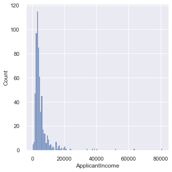

```python
sb.displot(train['ApplicantIncome'])
```

### Profile Report

Gives more detailed analysis of the variables in the training dataset

```python
ProfileReport(train)
```

[interactive chart not shown]

I'm curious why there are so many zeros on the coapplicant column

```python
train.groupby('Married')['CoapplicantIncome'].mean()
```

```
Married
0    1310.406542
1    1787.544800
Name: CoapplicantIncome, dtype: float64
```

```python
train.groupby('Gender')['CoapplicantIncome'].mean()
```

```
Gender
0    1088.570175
1    1742.695840
Name: CoapplicantIncome, dtype: float64
```

# Classification Models

I needed to split the training data again, I just noticed (yup, I didn't think I needed to check this, my bad future Me, my bad :-)) that the testing dataset I downloaded was does not have the target variable... so I would not have anything to compare the predicted values to. So I lost 367 observations... which is nice :-)

Consequently, I probably risked data leakage on this analysis. see: https://scikit-learn.org/stable/common_pitfalls.html#data-leakage

```python
trainees = [col for col in train.columns if col!="Loan_Status"]

X = train[trainees].copy(deep=True)
Y = train['Loan_Status']

x, x_test, y, y_test = train_test_split(X, Y, test_size=0.25, random_state=28)
```

## Metrics

writing functions to calculate classification metrics to test the effectiveness of the models on training data. The first function returns a dictionaru of the accuracy score, the precision score, confusion matrix and a classification report. The second function prints out each metric from the dictionary.

```python
def scores(model):
    '''Defines the metrics that the models will be using. Returns a dictionary with four sets of metrics'''
    global x_test, y_test
    accuracy = accuracy_score(y_true = y_test, y_pred= model.predict(x_test))*100
    precision = precision_score(y_true = y_test, y_pred= model.predict(x_test))*100
    classfication = classification_report(y_true = y_test, y_pred= model.predict(x_test))
    confusion = confusion_matrix(y_true = y_test, y_pred= model.predict(x_test))
    return {"Accuracy Score":accuracy, "Precision Score": precision, "Classification Report": classfication, "Confusion Matrix":confusion}

def print_results(results):
    '''This function takes the results from the scores function and prints out the result from each classification metric'''
    keys = results.keys()
    for key in keys:
        print(f'{key}: \n{results.get(key)}\n')
```

### Checking data distribution

sometimes the number of observations for our classes are wildly different... which affects model support

```python
# training data loan status

y.value_counts()
```

```
1    313
0    147
Name: Loan_Status, dtype: int64
```

```python
# testing data loan status

y_test.value_counts()
```

```
1    109
0     45
Name: Loan_Status, dtype: int64
```

NB: the distribution of the data, i.e. the support, is unbalance, we need both Approved and Unapproved to be relatively equal. The distribution is almost 1:2 for rejection:approval. This will probably have an impact on the model results.

## Logistic Regression

My birthday is on the 28th of some month.... sooooooooo my random_state is more like a constant state =D

```python
logistic = LogisticRegression(solver="liblinear", random_state=28)
```

```python
model_logistic = logistic.fit(y=y, X=x)
model_logistic_regression = pickle.dumps(model_logistic)
```

```python
print("Logistic regression model performance: \n")
print_results(scores(model_logistic))
```

```
Logistic regression model performance:

Accuracy Score:
85.71428571428571

Precision Score:
84.25196850393701

Classification Report:
              precision    recall  f1-score   support

           0       0.93      0.56      0.69        45
           1       0.84      0.98      0.91       109

    accuracy                           0.86       154
   macro avg       0.88      0.77      0.80       154
weighted avg       0.87      0.86      0.84       154


Confusion Matrix:
[[ 25  20]
 [  2 107]]
```

```python
forest = RandomForestClassifier(random_state=28)
```

```python
forest.fit(y=y, X=x)
```

```
RandomForestClassifier(random_state=28)
```

```python
model_forest = logistic.fit(y=y, X=x)
model_random_forest = pickle.dumps(model_forest)
```

```python
print("Random Forest model performance: \n")
print_results(scores(model_forest))
```

```
Random Forest model performance:

Accuracy Score:
85.71428571428571

Precision Score:
84.25196850393701

Classification Report:
              precision    recall  f1-score   support

           0       0.93      0.56      0.69        45
           1       0.84      0.98      0.91       109

    accuracy                           0.86       154
   macro avg       0.88      0.77      0.80       154
weighted avg       0.87      0.86      0.84       154


Confusion Matrix:
[[ 25  20]
 [  2 107]]
```

```python
tree = DecisionTreeClassifier(random_state=28)
```

```python
tree.fit(y=y, X=x)
```

```
DecisionTreeClassifier(random_state=28)
```

```python
model_tree = logistic.fit(y=y, X=x)
model_decision_tree = pickle.dumps(model_tree)
```

```python
print("Decision tree model performance: \n")
print_results(scores(model_tree))
```

```
Decision tree model performance:

Accuracy Score:
85.71428571428571

Precision Score:
84.25196850393701

Classification Report:
              precision    recall  f1-score   support

           0       0.93      0.56      0.69        45
           1       0.84      0.98      0.91       109

    accuracy                           0.86       154
   macro avg       0.88      0.77      0.80       154
weighted avg       0.87      0.86      0.84       154


Confusion Matrix:
[[ 25  20]
 [  2 107]]
```

```python
boost = XGBClassifier(random_state=28)
```

```python
boost.fit(y=y, X=x)
```

```
XGBClassifier(base_score=0.5, booster='gbtree', callbacks=None,
              colsample_bylevel=1, colsample_bynode=1, colsample_bytree=1,
              early_stopping_rounds=None, enable_categorical=False,
              eval_metric=None, gamma=0, gpu_id=-1, grow_policy='depthwise',
              importance_type=None, interaction_constraints='',
              learning_rate=0.300000012, max_bin=256, max_cat_to_onehot=4,
              max_delta_step=0, max_depth=6, max_leaves=0, min_child_weight=1,
              missing=nan, monotone_constraints='()', n_estimators=100,
              n_jobs=0, num_parallel_tree=1, predictor='auto', random_state=28,
              reg_alpha=0, reg_lambda=1, ...)
```

```python
model_boost = logistic.fit(y=y, X=x)
```

```python
model_xgboost = pickle.dumps(model_boost)
```

```python
print("XGBoost model performance: \n")
print_results(scores(model_boost))
```

```
XGBoost model performance:

Accuracy Score:
85.71428571428571

Precision Score:
84.25196850393701

Classification Report:
              precision    recall  f1-score   support

           0       0.93      0.56      0.69        45
           1       0.84      0.98      0.91       109

    accuracy                           0.86       154
   macro avg       0.88      0.77      0.80       154
weighted avg       0.87      0.86      0.84       154


Confusion Matrix:
[[ 25  20]
 [  2 107]]
```

## Model Performance

```python
print_results(scores(model_boost))
```

```
Accuracy Score:
85.71428571428571

Precision Score:
84.25196850393701

Classification Report:
              precision    recall  f1-score   support

           0       0.93      0.56      0.69        45
           1       0.84      0.98      0.91       109

    accuracy                           0.86       154
   macro avg       0.88      0.77      0.80       154
weighted avg       0.87      0.86      0.84       154


Confusion Matrix:
[[ 25  20]
 [  2 107]]
```

### Classification report visualisation

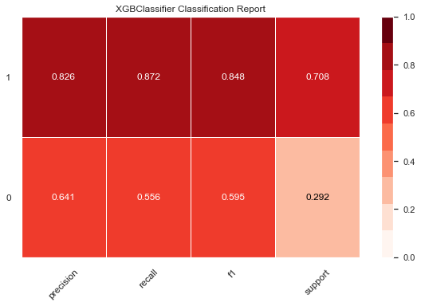

```
ClassificationReport(ax=<AxesSubplot:title={'center':'XGBClassifier Classification Report'}>,
                     cmap=<matplotlib.colors.ListedColormap object at 0x7fd70d39e1c0>,
                     estimator=XGBClassifier(base_score=0.5, booster='gbtree',
                                             callbacks=None,
                                             colsample_bylevel=1,
                                             colsample_bynode=1,
                                             colsample_bytree=1,
                                             early_stopping_rounds=None,
                                             enable_categorical=False,
                                             eval_metric=None...
                                             gpu_id=-1, grow_policy='depthwise',
                                             importance_type=None,
                                             interaction_constraints='',
                                             learning_rate=0.300000012,
                                             max_bin=256, max_cat_to_onehot=4,
                                             max_delta_step=0, max_depth=6,
                                             max_leaves=0, min_child_weight=1,
                                             missing=nan,
                                             monotone_constraints='()',
                                             n_estimators=100, n_jobs=0,
                                             num_parallel_tree=1,
                                             predictor='auto', random_state=28,
                                             reg_alpha=0, reg_lambda=1, ...),
                     support='percent')
```

```python
ClassificationReport(boost, x, y, x_test, y_test, support = 'percent', cmap = 'Reds', font_size = '16')
```

### Class Prediction Error

This is not too different to the confusion matrix. It also shows you where the model was most confused

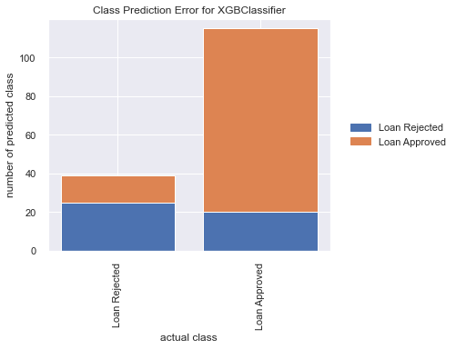

```
ClassPredictionError(ax=<AxesSubplot:title={'center':'Class Prediction Error for XGBClassifier'}, xlabel='actual class', ylabel='number of predicted class'>,
                     classes=['Loan Rejected', 'Loan Approved'],
                     estimator=XGBClassifier(base_score=0.5, booster='gbtree',
                                             callbacks=None,
                                             colsample_bylevel=1,
                                             colsample_bynode=1,
                                             colsample_bytree=1,
                                             early_stopping_rounds=None,
                                             enable_...
                                             eval_metric=None, gamma=0,
                                             gpu_id=-1, grow_policy='depthwise',
                                             importance_type=None,
                                             interaction_constraints='',
                                             learning_rate=0.300000012,
                                             max_bin=256, max_cat_to_onehot=4,
                                             max_delta_step=0, max_depth=6,
                                             max_leaves=0, min_child_weight=1,
                                             missing=nan,
                                             monotone_constraints='()',
                                             n_estimators=100, n_jobs=0,
                                             num_parallel_tree=1,
                                             predictor='auto', random_state=28,
                                             reg_alpha=0, reg_lambda=1, ...))
```

```python
#ClassPredictionError(boost, classes = ['Rejected', 'Approved']).fit(x, y).score(x_test, y_test)
class_prediction_error(boost, x, y, x_test, y_test, classes = ["Loan Rejected", 'Loan Approved'])
```

The model only classified slightly above half of the rejections correctly; the model seems to be giving out loans to everyone!

### Classification result analysis

NB: The models were not tuned, so default parameters were used.

## Saves the models to memory for future use

```python
pickle.dump(model_boost, open('xgboost.sav', 'wb'))
pickle.dump(model_tree, open('Decision tree.sav', 'wb'))
pickle.dump(model_logistic, open('logistic regression.sav', 'wb'))
pickle.dump(model_forest, open('random forest.sav', 'wb'))
```

# Soft deployment

Gets creates 'main'-like user engagement function (called get_loan() ) and a background method (called predictor()) to store, process the user input and give out the prediction

### predictor() function

I create a function which takes user-input and returns the prediction. I also overload the predictor() function to also accept a dictionary instead of just user-input; for demostrative purpose (It got tiring having to give user-input with every run)

```python
@dispatch()
def predictor():
    """This function will take user input in order to come up with an observation, stores the user input in a dictionary,
    reshapes the observation so that xgboost does not shout at us, uses the xgboost model results to make a preciction
    and results an array with the binary response; 0 if the loan is declined and 1 if it is approved"""
    time.sleep(2)
    slowprint('\nOh lovely!!\n\nI am going to let you know whether you qualify for a loan.\n\nPlease input the following information for me; And try to follow instructions:\n', 0.5)
    gender = int(input("Please input 1 for male and 0 for female:\n"))
    assert gender in [1,0], 'You failed to follow instructions :('

    married = int(input('Please type 1 for "married" or 0 for "not married": \n'))
    assert married in [1,0], 'You failed to follow instructions :('

    dependents = int(input("How many dependents do you have?: \n"))
    assert isinstance(dependents, numbers.Number), 'You failed to follow instructions :('

    education = int(input("Please input 1 if you have tertiary qualifications and 0 if you do not: \n"))
    assert education in [1,0], 'You failed to follow instructions :('

    self_employed = int(input("Please input 1 if you are self-employed, and 0 if you are not self-employed: \n"))
    assert self_employed in [1,0], 'You failed to follow instructions :('

    income = float(input("Please input your annual dollar income. Just the number, no currency: \n"))
    assert isinstance(income, numbers.Number), 'That income makes no sense. You have to start over :('

    coapplicant_income = float(input("Please input your co-applicant's income. Just the number, no currency: \n"))
    assert isinstance(coapplicant_income, numbers.Number), "You're single aren't you? Is that why you're making up numbers?"

    loan_amount = float(input("Please input the loan amount you are seeking in thousands \n e.g. input 5 if you need 5,000. Just enter the number, no currency:\n"))
    assert isinstance(loan_amount, numbers.Number), "You're single aren't you? Is that why you're making up numbers? Do you even need this loan?"

    loan_term = int(input("How long do you need to repay the loan? Please pick from the following available terms in months \n[360, 180,  36, 300, 480, 240, 120]: \n"))
    terms = [360, 180,  36, 300, 480, 240, 120]
    assert loan_term in terms, 'Where on earth did you get that number?'

    credit_history = int(input("Do you have credit history? Please input 1 for Yes and 0 for No: \n"))
    assert credit_history in [0, 1], "You were so close to finishing without f-ing up. oh well!!"

    property_area = int(input("What kind of area do you reside in? Input 0 for rural, 2 for urban or 1 for semi-urban: \n"))
    assert property_area in [1,0, 2], 'You failed to follow instructions. Should I add an option for the moon perhaps? :('

    my_dic = {'Gender': gender, 'Married': married, 'Dependents': dependents, 'Education': education, 'Self_Employed': self_employed,
       'ApplicantIncome': income, 'CoapplicantIncome': coapplicant_income, 'LoanAmount': loan_amount,
       'Loan_Amount_Term': loan_term, 'Credit_History': credit_history, 'Property_Area': property_area}

    return model_boost.predict(pd.Series(my_dic).array.reshape(1, -1))

@dispatch (dict)
def predictor(my_dic):
   '''Overloading the method to also accept a dictionary with the inputs'''
   return model_boost.predict(pd.Series(my_dic).array.reshape(1, -1))
```

### Loan Application responses

Yes I could have just said loan declined or approved, but where's the fun in that...?

```python
# creates witty responses to loan applications
# get_loan() will randomly pick one of these responses depending on result of the application

negative_response = ["Yeah no we're not giving you money. Thanks for trying tho!", "Loan declined :(", "Fortunately, we have decided not to burden you with debt", "Unfortunately we have decided not to proceed with the loan. Ya broke!", "You are too poor to be asking us for money. Go away!", "Congratulations! You are going to stay broke!", "Management decided to halt giving out loans literally two seconds ago :("]
positive_response = ["Congratulations!! we have decided to give you a bunch of money...!!", "Loan approved! Congratulations!", "Fine. You can have our money!", "Unfortunately, we have decided to give you a bunch of debts!", "Yay!! Your loan was approved. Don't come for more!", "You're rich enough to associate with us!!", "We're happy to approve your loan!"]
```

### get_loan() function

get_loan() function acts as the user interface, gets the user input, gives loan application results and prompts whether they would like to make another loan application.

```python
def get_loan ():
    print(90*"=")
    print(31*" ",'Welcome to the Bank of Loans!!\n',90*"=", '\n', sep = "")
    query = int(input('Do you want to apply for a loan? Input 1 for yes, or 0 for No: \n'))
    assert query in [1, 0], "Something went wrong. Dafuq did you do?"
    if query == 0:
        print("Well that's disappointing! You probably also disappointed your parents didn't you?!? :)", f"\n\n{25*' '}Well Byyeeeee!!!")
    elif query == 1:
        while query == 1:
            prediction = predictor()[0]
            print("Processing loan application ", end='')
            slowprint(".....", 3)
            if prediction == 1:
                slowprint(random.choice(positive_response), 1)
                print(90*'=')
                query = int(input('Do you wish to apply for another loan? Input 1 for yes, or 0 for No: \n'))
                assert query in [1, 0], "Something went wrong. What on God's earth did press?"
            else:
                slowprint(random.choice(negative_response), 1)
                print(90*'=')
                query = int(input('Do you wish to apply for another loan? Input 1 for yes, or 0 for No: \n'))
                assert query in [1, 0], "Something went wrong. It's probably your fault, my code is flawless"
```

## Example

This is the loan application of sub-urban married man with 2 kids. He is as graduate and earns $ 500,000 from his corporate job. Mr Guy's wife earns $ 25,000. The family needs a $ 10,000 loan to pay for their teenage daughter's tuition and accomodation to be repaid over 10 years. He has solid credit history from purchasing his house years earlier. This info is contained in the dictionary below.

```python
# The variable name is obviously short for My Dictionary

my_dic = {'Gender': 1, 'Married': 1, 'Dependents': 2, 'Education': 1, 'Self_Employed': 0,
       'ApplicantIncome': 500000, 'CoapplicantIncome': 25000, 'LoanAmount': 10000,
       'Loan_Amount_Term': 120, 'Credit_History': 1, 'Property_Area': 1}
```

```python
prediction = predictor(my_dic)

print("Decision: ")
if prediction == 1:
    slowprint(random.choice(positive_response), 1)
    print(90*'=')
    query = int(input('Do you wish to apply for another loan? Input 1 for yes, or 0 for No: \n'))
    assert query in [1, 0], "Something went wrong. What on God's earth did press?"
else:
    slowprint(random.choice(negative_response), 1)
    print(90*'=')
    query = int(input('Do you wish to apply for another loan? Input 1 for yes, or 0 for No: \n'))
    assert query in [1, 0], "Something went wrong. It's probably your fault, my code is flawless"
```

```
Decision:
Congratulations! You are going to stay broke!
==========================================================================================
Do you wish to apply for another loan? Input 1 for yes, or 0 for No:
0
```

He wants a $10000 loan facility to buy a new bike he has always wanted. He has solid credit history from purchasing his mansion years earlier. This info is contained in the dictionary below.

```python
my_dic = {'Gender': 1, 'Married':0 , 'Dependents': 0, 'Education': 1, 'Self_Employed': 0,
       'ApplicantIncome': 50000000, 'CoapplicantIncome': 0, 'LoanAmount': 10000,
       'Loan_Amount_Term': 120, 'Credit_History': 1, 'Property_Area': 0}
```

```python
prediction = predictor(my_dic)

print("Decision: ")
if prediction == 1:
    slowprint(random.choice(positive_response), 1)
    print(90*'=')
    query = int(input('Do you wish to apply for another loan? Input 1 for yes, or 0 for No: \n'))
    assert query in [1, 0], "Something went wrong. What on God's earth did press?"
else:
    slowprint(random.choice(negative_response), 1)
    print(90*'=')
    query = int(input('Do you wish to apply for another loan? Input 1 for yes, or 0 for No: \n'))
    assert query in [1, 0], "Something went wrong. It's probably your fault, my code is flawless"
```

```
Decision:
You're rich enough to associate with us!!
==========================================================================================
Do you wish to apply for another loan? Input 1 for yes, or 0 for No:
0
```